# 431 Class 05

Thomas E. Love, Ph.D.

2026-09-08

## Today’s Agenda

- The `dm464` study
  - Data stored in an Excel spreadsheet, rather than a `.csv` file
  - Data on 464 adults with diabetes between the ages of 18 and 73
- Estimating the Difference between Two Population Means
  - when our samples are paired
  - when our samples are independent
- Comparisons and estimates built using
  - ordinary least squares linear models (and their t-based equivalents),
  - the bootstrap, and
  - Bayesian linear models
- Chapters 5-6 of [Dr. Love’s book](https://thomaselove.github.io/431-book/) have more.

## Load packages and set theme

```r
knitr::opts_chunk$set(comment = NA)
source("c05/data/Love-431.R") # for the lovedist() function

library(janitor)
library(patchwork)
library(rstanarm)

library(readxl)     ## new today
library(knitr)      ## new (sort of) today
library(kableExtra) ## new today
library(ggdist)     ## new today
library(MKinfer)    ## new today

library(easystats)
library(tidyverse)

theme_set(theme_bw())
```

# Managing the `dm464` Data

## Today’s data (`dm464.xlsx`)

The data describe a cohort of 464 adults measured in a one-year baseline window, and then again in a similar window two years after baseline.

- The data in `dm464` are simulated, but mirror real data gathered by [Better Health Partnership](https://www.betterhealthpartnership.org/).
- The `dm464` data are restricted to people ages 18-73 at baseline, with a diabetes diagnosis who spoke English as their primary language, who lived in Cuyahoga County, and for whom multiple primary care visits were observed in the baseline and follow-up periods.

## Data are in an Excel Sheet

- Stored in an Excel worksheet called `dm464.xlsx`, rather than in a `.csv` file.

[figure not shown]

## Pulling in the `dm464` data

Ingest the data with `read_xlsx()` from **readxl** package<sup>1</sup>.

```r
dm464_raw <- read_xlsx("c05/data/dm464.xlsx")
dim(dm464_raw)
```

```
[1] 464  42
```

```r
names(dm464_raw)
```

```
 [1] "id-code"       "AGE_start"     "RACE_NEW"      "HISP"
 [5] "SEX"           "INSUR_start"   "LANG"          "NINC_start"
 [9] "NEDLEV_start"  "SBP_start"     "DBP_start"     "SBP_end"
[13] "DBP_end"       "A1C_start"     "A1C_end"       "LDL_start"
[17] "LDL_end"       "HEIGHT_start"  "WEIGHT_start"  "BMI_start"
[21] "HEIGHT_end"    "WEIGHT_end"    "BMI_end"       "SMOKE_start"
[25] "SMOKE_end"     "STATIN_start"  "STATIN_end"    "ACEARB_start"
[29] "ACEARB_end"    "BETAB_start"   "BETAB_end"     "EYEEX_start"
[33] "EYEEX_end"     "PNEUMO_start"  "PNEUMO_end"    "DEPDIAG_start"
[37] "DEPDIAG_end"   "HOME_start"    "HOME_end"      "INSUR_end"
[41] "NINC_end"      "NEDLEV_end"
```

[^1]: Excel file downloaded to the `c05/data` subdirectory of my R project directory.

## Auto-cleaning variable names

```r
dm464 <- dm464_raw |> janitor::clean_names()

names(dm464)
```

```
 [1] "id_code"       "age_start"     "race_new"      "hisp"
 [5] "sex"           "insur_start"   "lang"          "ninc_start"
 [9] "nedlev_start"  "sbp_start"     "dbp_start"     "sbp_end"
[13] "dbp_end"       "a1c_start"     "a1c_end"       "ldl_start"
[17] "ldl_end"       "height_start"  "weight_start"  "bmi_start"
[21] "height_end"    "weight_end"    "bmi_end"       "smoke_start"
[25] "smoke_end"     "statin_start"  "statin_end"    "acearb_start"
[29] "acearb_end"    "betab_start"   "betab_end"     "eyeex_start"
[33] "eyeex_end"     "pneumo_start"  "pneumo_end"    "depdiag_start"
[37] "depdiag_end"   "home_start"    "home_end"      "insur_end"
[41] "ninc_end"      "nedlev_end"
```

- Here’s a nice [overview of janitor functions](https://cran.r-project.org/web/packages/janitor/vignettes/janitor.html). By default, names are parsed to `snake_case` but other options exist.

## Today’s Seven Variables

| Variable | Definition |
| --- | --- |
| `id_code` | Subject Code (unique for each row) |
| `age_start` | baseline age, in years |
| `sex` | Female or Male |
| `a1c_start` | baseline Hemoglobin A1c, % |
| `a1c_end` | Hemoglobin A1c at study end, % |
| `ldl_start` | baseline LDL cholesterol, mg/dl |
| `statin_start` | baseline: Statin prescribed? (1 or 0) |

## Select (and Rename) Variables

Let’s select our variables, and simplify some names.

```r
class05 <- dm464 |>
  select(id_code, age = age_start, sex, a1c_base = a1c_start,
         a1c_end, ldl = ldl_start, statin = statin_start)

str(class05)
```

```
tibble [464 × 7] (S3: tbl_df/tbl/data.frame)
 $ id_code : chr [1:464] "DM-1007" "DM-1017" "DM-1039" "DM-1049" ...
 $ age     : num [1:464] 63 56 53 52 55 61 68 56 67 64 ...
 $ sex     : chr [1:464] "Female" "Male" "Female" "Female" ...
 $ a1c_base: num [1:464] 9.5 6.2 6.6 7 5.3 6.9 11.1 8.3 10.5 5.7 ...
 $ a1c_end : num [1:464] 9 6.5 7 6.7 5.6 7 9.8 8.8 13.1 5.4 ...
 $ ldl     : num [1:464] 203 88 139 188 112 81 167 89 135 68 ...
 $ statin  : num [1:464] 1 1 1 1 0 1 0 1 1 0 ...
```

## Change characters to factors

- The `sex` variable is listed as character, but we’d like it instead to be represented as a *factor*.
  - The `id_code` should remain as a character variable.
- We’ll also add a factor version of the `statin` variable (`stat_f` is binary: with 1 = statin, and 0 = no)

```r
class05 <- class05 |>
  mutate(sex = as_factor(sex)) |>
  mutate(stat_f = fct_recode(as_factor(statin), "statin" = "1", "no" = "0"))
```

## Checking our work

- Do the `stat_f` and `statin` variables agree?

```r
class05 |> count(statin, stat_f)
```

```
# A tibble: 2 × 3
  statin stat_f     n
   <dbl> <fct>  <int>
1      0 no        97
2      1 statin   367
```

- Do we have a different `id_code` in each row?

```r
nrow(class05)
```

```
[1] 464
```

```r
class05 |> select(id_code) |> n_distinct()
```

```
[1] 464
```

## Missingness? Range checks? Types?

```r
summary(class05)
```

```
      id_code         age            sex         a1c_base         a1c_end
 Length   :464   Min.   :21.00   Female:288   Min.   : 4.200   Min.   : 4.400
 N.unique :464   1st Qu.:51.00   Male  :176   1st Qu.: 6.200   1st Qu.: 6.400
 N.blank  :  0   Median :58.00                Median : 7.000   Median : 7.300
 Min.nchar:  7   Mean   :57.57                Mean   : 7.564   Mean   : 7.895
 Max.nchar:  7   3rd Qu.:65.00                3rd Qu.: 8.325   3rd Qu.: 9.000
                 Max.   :73.00                Max.   :14.900   Max.   :17.000
      ldl            statin          stat_f
 Min.   : 40.0   Min.   :0.0000   no    : 97
 1st Qu.: 76.0   1st Qu.:1.0000   statin:367
 Median : 92.0   Median :1.0000
 Mean   :101.9   Mean   :0.7909
 3rd Qu.:122.2   3rd Qu.:1.0000
 Max.   :231.0   Max.   :1.0000
```

- Revised “codebook” on next slide

| Variable | Definition (`class05` tibble) |
| --- | --- |
| `id_code` | subject code |
| `age` | baseline age, in years |
| `sex` | Female or Male |
| `a1c_base` | baseline Hemoglobin A1c, % |
| `a1c_end` | Hemoglobin A1c at study end, % |
| `ldl` | baseline LDL cholesterol, mg/dl |
| `statin` | baseline: Statin prescribed? (1 or 0) |
| `stat_f` | `statin` as factor (1 = `statin`, 0 = `no`) |

## Our `class05` analytic tibble

```r
class05
```

```
# A tibble: 464 × 8
   id_code   age sex    a1c_base a1c_end   ldl statin stat_f
   <chr>   <dbl> <fct>     <dbl>   <dbl> <dbl>  <dbl> <fct>
 1 DM-1007    63 Female      9.5     9     203      1 statin
 2 DM-1017    56 Male        6.2     6.5    88      1 statin
 3 DM-1039    53 Female      6.6     7     139      1 statin
 4 DM-1049    52 Female      7       6.7   188      1 statin
 5 DM-1064    55 Female      5.3     5.6   112      0 no
 6 DM-1070    61 Female      6.9     7      81      1 statin
 7 DM-1076    68 Female     11.1     9.8   167      0 no
 8 DM-1095    56 Female      8.3     8.8    89      1 statin
 9 DM-1110    67 Male       10.5    13.1   135      1 statin
10 DM-1143    64 Female      5.7     5.4    68      0 no
# ℹ 454 more rows
```

## Saving and Loading a tibble

We can save the `class05` tibble to a file, for instance …

```r
write_rds(class05, "c05/data/class05.Rds")
```

which we can then reload whenever we like with …

```r
class05_read <- read_rds("c05/data/class05.Rds")

identical(class05, class05_read)
```

```
[1] TRUE
```

# Six Key “Verbs” for Data Management

## 6 key data management “verbs”

- `filter()` chooses rows
- `select()` chooses columns
- `arrange()` sorts rows by values
- `mutate()` creates new columns
- `group_by()` manipulates groups of data
- `summarize()` provides numerical summaries

All of these are in the `dplyr` package; part of the **tidyverse**. See the [Data Transformation chapter of R4DS](https://r4ds.hadley.nz/data-transform.html).

## `filter()`

We use the `filter()` function to change which rows are present in the data, without changing the order.

```r
class05 |> filter(sex == "Female", age < 30)
```

```
# A tibble: 4 × 8
  id_code   age sex    a1c_base a1c_end   ldl statin stat_f
  <chr>   <dbl> <fct>     <dbl>   <dbl> <dbl>  <dbl> <fct>
1 DM-1617    21 Female      7.8     5.6   114      0 no
2 DM-1681    23 Female      7.2    10.9   128      1 statin
3 DM-4953    29 Female      8.5     6.6   146      1 statin
4 DM-5252    27 Female      9.6     9.2   128      1 statin
```

## `select()`

We use the `select()` function to change which columns are present…

```r
class05 |> select(id_code, a1c_base, a1c_end)
```

```
# A tibble: 464 × 3
   id_code a1c_base a1c_end
   <chr>      <dbl>   <dbl>
 1 DM-1007      9.5     9
 2 DM-1017      6.2     6.5
 3 DM-1039      6.6     7
 4 DM-1049      7       6.7
 5 DM-1064      5.3     5.6
 6 DM-1070      6.9     7
 7 DM-1076     11.1     9.8
 8 DM-1095      8.3     8.8
 9 DM-1110     10.5    13.1
10 DM-1143      5.7     5.4
# ℹ 454 more rows
```

## `arrange()`

We use `arrange()` to change the order of the rows based on their values.

```r
class05 |> arrange(a1c_base) |>
  select(id_code, a1c_base, a1c_end)
```

```
# A tibble: 464 × 3
   id_code a1c_base a1c_end
   <chr>      <dbl>   <dbl>
 1 DM-3822      4.2     4.4
 2 DM-9713      5       5.3
 3 DM-9795      5.1     4.5
 4 DM-9899      5.1     7.6
 5 DM-1064      5.3     5.6
 6 DM-1713      5.3     6.3
 7 DM-4269      5.3     6
 8 DM-6656      5.3     4.6
 9 DM-8526      5.3     5.5
10 DM-8827      5.3     5.8
# ℹ 454 more rows
```

## `mutate()`

We use `mutate()` to add new columns calculated from the existing columns.

```r
class05 |> select(id_code, a1c_base, a1c_end) |>
  mutate(a1c_change = a1c_end - a1c_base)
```

```
# A tibble: 464 × 4
   id_code a1c_base a1c_end a1c_change
   <chr>      <dbl>   <dbl>      <dbl>
 1 DM-1007      9.5     9      -0.5
 2 DM-1017      6.2     6.5     0.300
 3 DM-1039      6.6     7       0.400
 4 DM-1049      7       6.7    -0.300
 5 DM-1064      5.3     5.6     0.300
 6 DM-1070      6.9     7       0.1000
 7 DM-1076     11.1     9.8    -1.30
 8 DM-1095      8.3     8.8     0.5
 9 DM-1110     10.5    13.1     2.6
10 DM-1143      5.7     5.4    -0.300
# ℹ 454 more rows
```

## `group_by()` and `summarize()`

We use `group_by()` to divide the data in groups of interest then use `summarize()` to obtain summaries.

```r
class05 |> select(id_code, sex, a1c_base, a1c_end) |>
  mutate(a1c_change = a1c_end - a1c_base) |>
  group_by(sex) |> summarize(n = n(), median = median(a1c_change))
```

```
# A tibble: 2 × 3
  sex        n median
  <fct>  <int>  <dbl>
1 Female   288  0.200
2 Male     176  0.400
```

We’ve used this `group_by()` approach, with `lovedist()`, too.

## Today’s Analytic Questions

We’ll use the `class05` tibble to address these two questions…

1. How large is the difference in the mean Hemoglobin A1c level at baseline as compared to the A1c level in the follow-up period?
2. How large is the difference in the mean LDL cholesterol level at baseline for people who have a statin prescription at baseline, as compared to those who don’t?

# Comparing Means

## Paired Samples Comparisons

Suppose we want to compare the weights of mice:

- **before** they are switched to a new diet, vs.
- **after** they have been on the new diet for 2 weeks

In our sample of (say) 100 mice, each mouse provides a *pair* of measurements, and we can calculate the change in weight for each mouse:

| mouse | before | after | change |
| --- | --- | --- | --- |
| A-001 | 14 | 16 | 2 |
| A-002 | 18 | 17 | -1 |

## Paired Samples and our Mice

We want to make estimates using data on those 100 changes in weight to describe what might happen in a larger population of mice who switched diets.

- Each mouse’s “before” and “after” data, then, describes two *paired* samples.

We compare means (or other summaries) using paired samples whenever data are gathered so that the responses from the two groups being compared (here, before and after) are paired (or matched.)

## Independent Samples

Suppose we want to compare the weights of mice who are on diet A, vs. mice who are on diet B.

We sample 50 mice on diet A and 50 different mice on diet B<sup>1</sup>. Each mouse provides a weight after their selected diet, and there is no pre-planned pairing of individual diet A mice to diet B mice.

| mouse | diet | weight |
| --- | --- | --- |
| A-101 | A | 18 |
| B-102 | B | 15 |

[^2]: Maybe we started with 100 mice, and randomly assigned 50 to each diet.

## Independent Samples & Mice

We then make estimates using the weights of all 100 sampled mice to describe what might happen in a larger population comparing diet A to B.

- Each mouse provides an “A” or “B” weight, and the samples are not paired, but rather *independent*.

We compare means (or other summaries) using independent samples whenever we have data gathered so that the responses from the two groups being compared (here, A and B) are **not** paired (or matched.)

# Question 1

## Comparing `a1c_base` to `a1c_end`

1. How large is the difference in the mean Hemoglobin A1c level at baseline as compared to the A1c level in the follow-up period?

We are comparing each subject’s `a1c_base` to their `a1c_end`, to learn what our sample might tell us about the mean of those differences.

- Does this planned analysis make use of paired samples or independent samples?
  - What do you think?

## Paired or Independent Samples?

Does this planned analysis make use of paired samples or independent samples?

- Each subject provides an `a1c_base` as well as an `a1c_end`.
- Calculating the difference (`a1c_end` - `a1c_base`) makes sense for each individual subject.
- This will leave us with $n = 464$ paired differences to study.

## Paired A1c samples…

- How are the samples paired?

```r
class05 |> select(id_code, a1c_base, a1c_end)
```

```
# A tibble: 464 × 3
   id_code a1c_base a1c_end
   <chr>      <dbl>   <dbl>
 1 DM-1007      9.5     9
 2 DM-1017      6.2     6.5
 3 DM-1039      6.6     7
 4 DM-1049      7       6.7
 5 DM-1064      5.3     5.6
 6 DM-1070      6.9     7
 7 DM-1076     11.1     9.8
 8 DM-1095      8.3     8.8
 9 DM-1110     10.5    13.1
10 DM-1143      5.7     5.4
# ℹ 454 more rows
```

## Build the paired A1c differences

```r
class05 <- class05 |>
  mutate(a1c_diff = a1c_end - a1c_base)

class05 |> reframe(lovedist(a1c_diff))
```

```
# A tibble: 1 × 10
      n  miss  mean    sd   med   mad   min   q25   q75   max
  <int> <int> <dbl> <dbl> <dbl> <dbl> <dbl> <dbl> <dbl> <dbl>
1   464     0 0.332  1.79 0.200  1.19  -5.9  -0.5   1.1   8.9
```

Could also use `summary()`, `fivenum()`, `describe_distribution()`, `mean_sd`, `median_mad`, `summarize()`, etc. to obtain various numerical summaries in this case.

## Make a prettier table?

Using the **knitr** package…

```r
class05 |> reframe(lovedist(a1c_diff)) |>
  kable(digits = 2)
```

| n | miss | mean | sd | med | mad | min | q25 | q75 | max |
| --- | --- | --- | --- | --- | --- | --- | --- | --- | --- |
| 464 | 0 | 0.33 | 1.79 | 0.2 | 1.19 | -5.9 | -0.5 | 1.1 | 8.9 |

or, using the **knitr** and **kableExtra** packages…

```r
class05 |> reframe(lovedist(a1c_diff)) |>
  kable(digits = 2) |> kable_styling(font_size = 28)
```

| n | miss | mean | sd | med | mad | min | q25 | q75 | max |
| --- | --- | --- | --- | --- | --- | --- | --- | --- | --- |
| 464 | 0 | 0.33 | 1.79 | 0.2 | 1.19 | -5.9 | -0.5 | 1.1 | 8.9 |

## Standard Deviation (`sd` in R)

- Find the mean of the $n$ observations in your data, $\bar{x}$.
- Find the squared difference between each data point $x_i$ and the mean $\bar{x}$.
- Sum these squared differences.
- Divide the sum by $n-1$.
- This gives the **variance**.
- The square root of the variance is the **standard deviation**.

$$s = \sqrt{\frac{\sum_{i=1}^{n}{(x_i - \bar{x})^2}}{n-1}}$$

- The standard deviation is more often used to measure variation than the variance because the standard deviation has the same units of measurement as the mean.

## Median Absolute Deviation

The median absolute deviation (MAD) is the median of the absolute deviations from the sample median, so if $x_{med}$ is the sample median of a set of $n$ observations, the MAD is:

$$MAD = median(|x_i - x_{MED}|) \times 1.4826$$

- The purpose of multiplying by the constant is so that if data come from a Normal distribution, the MAD (with this multiplication) and the standard deviation will have the same value.
- See [Appendix E of Dr. Love’s Course Book](https://thomaselove.github.io/431-book/formulas.html) for detailed descriptions of key summaries.

## DTDP: Paired A1c differences

```r
ggplot(data = class05, aes(x = a1c_diff)) +
  geom_histogram(bins = 20, fill = "#002D72", col = "#FF5910") +
  labs(title = "Paired difference in A1c (end - baseline)",
       subtitle = "n = 464 subjects",
       x = "Difference in A1c (end - baseline)", y = "Subjects")
```

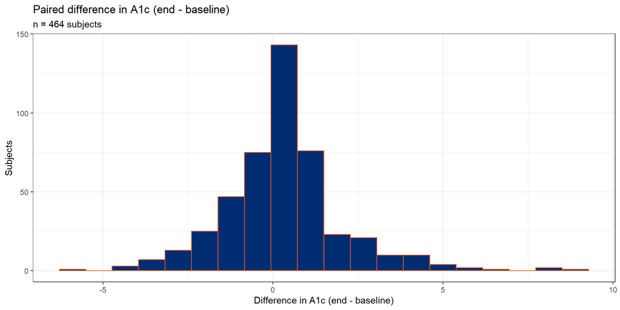

## What does the distribution of A1c differences look like? (1/4)

- Plot `p1` - Histogram with superimposed Normal curve

```r
bw = 1 # specify width of bins in histogram

p1 <- ggplot(class05, aes(x = a1c_diff)) +
  geom_histogram(binwidth = bw, fill = "black", col = "yellow") +
  stat_function(fun = function(x)
    dnorm(x, mean = mean(class05$a1c_diff, na.rm = TRUE),
          sd = sd(class05$a1c_diff, na.rm = TRUE)) *
          length(class05$a1c_diff) * bw,
    geom = "area", alpha = 0.5,
    fill = "lightblue", col = "blue") +
  labs(x = "A1c difference (%)", y = "Count",
       title = "Histogram & Normal Curve")
```

## What does the distribution of A1c differences look like? (2/4)

- Plot `p2` - Normal Q-Q plot

```r
p2 <- ggplot(class05, aes(sample = a1c_diff)) +
  geom_qq() + geom_qq_line(col = "red") +
  labs(y = "A1c difference (%)", x = "Standard Normal Distribution",
    title = "Normal Q-Q plot")
```

## What does the distribution of A1c differences look like? (3/4)

- Plot `p3` - Boxplot with violin and mean

```r
p3 <- ggplot(class05, aes(x = a1c_diff, y = "")) +
  geom_violin(fill = "cornsilk") +
  geom_boxplot(width = 0.2) +
  stat_summary(fun = mean, geom = "point", shape = 16, col = "red") +
  labs(y = "", x = "A1c difference (%)", title = "Boxplot with Violin")
```

## Shape of the distribution? (4/4)

- Use the patchwork package to combine plots `p1`, `p2` and `p3` into a single figure
- See [section 2.4.6 in our Course Book](https://thomaselove.github.io/431-book/02_viz.html#three-plots-at-once) for similar “Three Plots At Once” code.

```r
p1 +
  (p2 / p3 + plot_layout(heights = c(2, 1))) +
  plot_annotation(title = "class05: Differences in A1c")
```

## Shape of the distribution? (4/4)

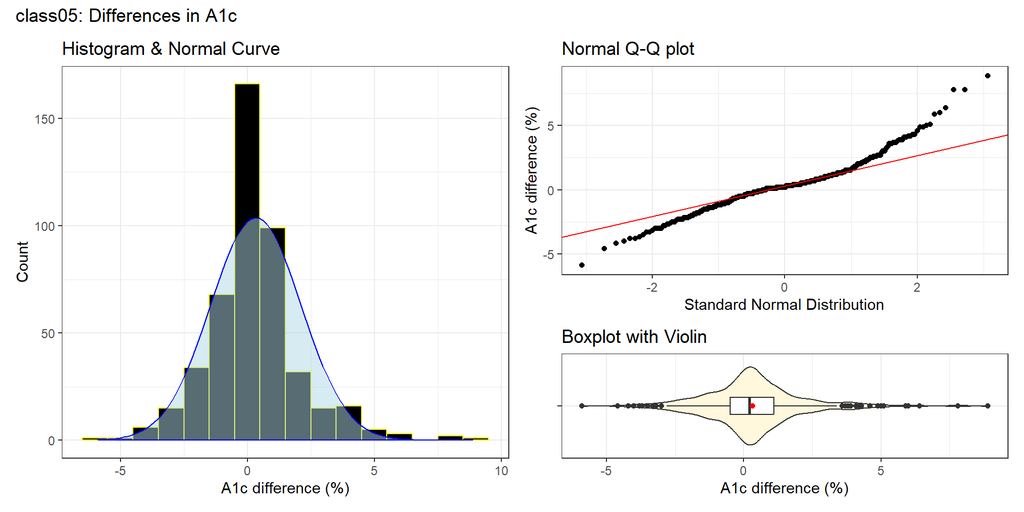

## Summaries of A1c differences

OK, so the distribution of A1c differences looks symmetric, but outlier-prone relative to a Normal distribution.

- Let’s look again at our numerical summaries…

```r
class05 |> reframe(lovedist(a1c_diff)) |>
  kable(digits = 2) |>
  kable_styling(font_size = 28)
```

| n | miss | mean | sd | med | mad | min | q25 | q75 | max |
| --- | --- | --- | --- | --- | --- | --- | --- | --- | --- |
| 464 | 0 | 0.33 | 1.79 | 0.2 | 1.19 | -5.9 | -0.5 | 1.1 | 8.9 |

- What does the sample mean (0.33) suggest in this context?

# Standing Break

## Estimating the Mean Difference

We’ll demonstrate three ways to estimate the population mean difference in A1c, and form a **90% uncertainty interval** using these paired samples<sup>1</sup>.

- Ordinary least squares regression model (equivalent to a paired t procedure here) fit with `lm()`.
- Bayesian regression model with a weakly informative prior, fit with `stan_glm()` from **rstanarm**.
- Bootstrap confidence interval for the mean difference, fit with `boot.t.test()` from **MKinfer**.
[^3]: [Chapter 5 of Dr. Love’s book](https://thomaselove.github.io/431-book/05_paired.html) has more details and examples.

## Using `lm()` to fit an OLS model

```r
fit1 <- lm(a1c_diff ~ 1, data = class05)

model_parameters(fit1, ci = 0.90, pretty_names = FALSE)
```

```
Parameter   | Coefficient |   SE |       90% CI | t(463) |      p
-----------------------------------------------------------------
(Intercept) |        0.33 | 0.08 | [0.20, 0.47] |   4.00 | < .001
```

- Sample mean difference is 0.33, with 90% uncertainty interval (0.20, 0.47).
- All three of these summaries are positive numbers. What does that indicate?

## Paired t approach = same as OLS

- Note that here we must include `conf.level = 0.90` within the `t.test()` command and `ci = 0.90` in the call to `model_parameters()` in order to get the right (90%) uncertainty interval.

```r
fit2 <- t.test(class05$a1c_diff, conf.level = 0.90)
model_parameters(fit2, ci = 0.90, pretty_names = FALSE)
```

```
One Sample t-test

Parameter | Mean | mu | Difference |       90% CI | t(463) |      p
-------------------------------------------------------------------
a1c_diff  | 0.33 |  0 |       0.33 | [0.20, 0.47] |   4.00 | < .001

Alternative hypothesis: true mean is not equal to 0
```

## Bayesian fit

Bayesian inference is an excellent choice for virtually every regression model, even when using **weakly informative default priors** (as we will do in 431), because it yields estimates which are stable, and because it helps present uncertainty in useful ways.

```r
set.seed(43101)
fit3 <- stan_glm(a1c_diff ~ 1, data = class05, refresh = 0)
model_parameters(fit3, ci = 0.90, pretty_names = FALSE)
```

```
Parameter   | Median |       90% CI |   pd |  Rhat | ESS (tail) |                 Prior
---------------------------------------------------------------------------------------
(Intercept) |   0.33 | [0.20, 0.47] | 100% | 1.000 |       2157 | Normal (0.33 +- 4.46)
```

## The bootstrap (with `MKinfer`)

```r
set.seed(43102)
boot.t.test(class05$a1c_diff, conf.level = 0.90, R = 2000)
```

```
    Bootstrap One Sample t-test

data:  class05$a1c_diff
number of bootstrap samples:  2000
bootstrap p-value < 5e-04
bootstrap mean of x (SE) = 0.3318219 (0.08270615)
90 percent bootstrap percentile confidence interval:
 0.1974030 0.4762931

Results without bootstrap:
t = 4.0016, df = 463, p-value = 7.323e-05
alternative hypothesis: true mean is not equal to 0
90 percent confidence interval:
 0.1950719 0.4682901
sample estimates:
mean of x
 0.331681
```

## 90% Uncertainty Intervals

Estimating the mean of the paired differences in Hemoglobin A1c levels from baseline to study end…

| Approach | Estimate & 90% Interval |
| --- | --- |
| Linear model / Paired t | 0.33 (0.20, 0.47) |
| Bayesian fit: `stan_glm()` | 0.33 (0.20, 0.47) |
| Bootstrap: `boot.t.test()` | 0.33 (0.197, 0.476) |

- Do our conclusions change here?

## Are our paired A1c values correlated?

- Here, we see a meaningful and positive correlation between the paired A1c values, suggesting that the pairing helped to reduce nuisance variation.

```r
class05 |> select(a1c_base, a1c_end) |> correlation()
```

```
# Correlation Matrix (pearson-method)

Parameter1 | Parameter2 |    r |       95% CI | t(462) |         p
------------------------------------------------------------------
a1c_base   |    a1c_end | 0.60 | [0.53, 0.65] |  15.98 | < .001***

p-value adjustment method: Holm (1979)
Observations: 464
```

# Question 2

## Comparing `ldl` by `statin` level

We’ll build a boxplot, including violins and means.

```r
ggplot(class05, aes(x = ldl, y = stat_f,
                fill = stat_f)) +
  geom_violin() +
  geom_boxplot(width = 0.3, fill = "white") +
  stat_summary(fun = mean, geom = "point", shape = 16, size = 3,
               col = "red") +
  scale_fill_viridis_d(alpha = 0.3) +
  guides(fill = "none") +
  labs(title = "LDL by Statin Prescription Status",
       x = "Most recent LDL in the baseline period, in mg/dl",
       y = "Statin Prescription at end of baseline period")
```

## Comparing `ldl` by `statin` level

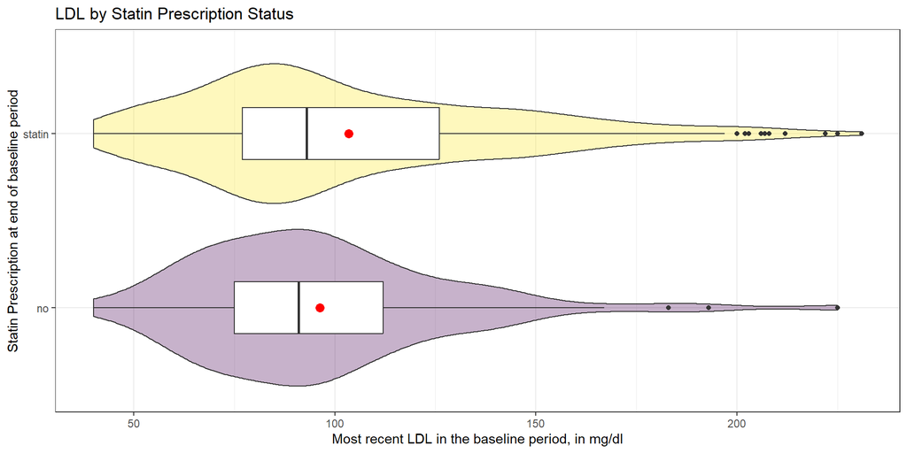

## Rain Cloud Plot

This plot includes `stat_slab()` and `stat_dotsinterval()` from the **ggdist** package.

```r
ggplot(class05, aes(y = stat_f, x = ldl, fill = stat_f)) +
  stat_slab(aes(thickness = after_stat(pdf * n)), scale = 0.7) +
  stat_dotsinterval(side = "bottom", scale = 0.7,
                    slab_linewidth = NA) +
  scale_fill_viridis_d(alpha = 0.7, begin = 0.2) +
  guides(fill = "none") +
  labs(title = "LDL by Statin Prescription Status",
       x = "Most recent LDL in the baseline period, in mg/dl",
       y = "Statin Prescription at end of baseline period")
```

## Rain Cloud Plot

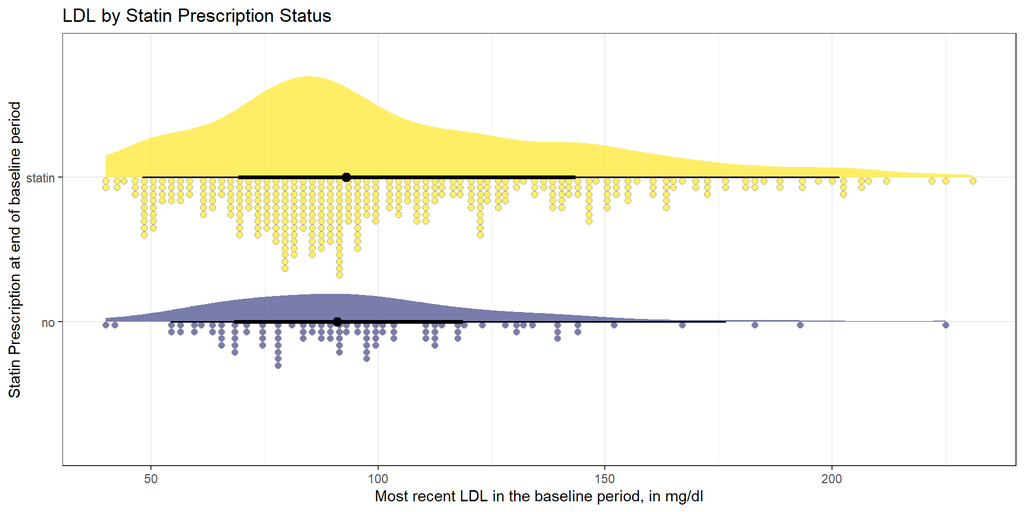

## Faceted Histograms

```r
bw = 5
ggplot(class05, aes(x = ldl)) +
  geom_histogram(binwidth = bw, fill = "navy", col = "white") +
  facet_wrap(~ stat_f) +
  labs(x = "LDL at baseline", y = "Counts",
       title = "LDL by Statin Status")
```

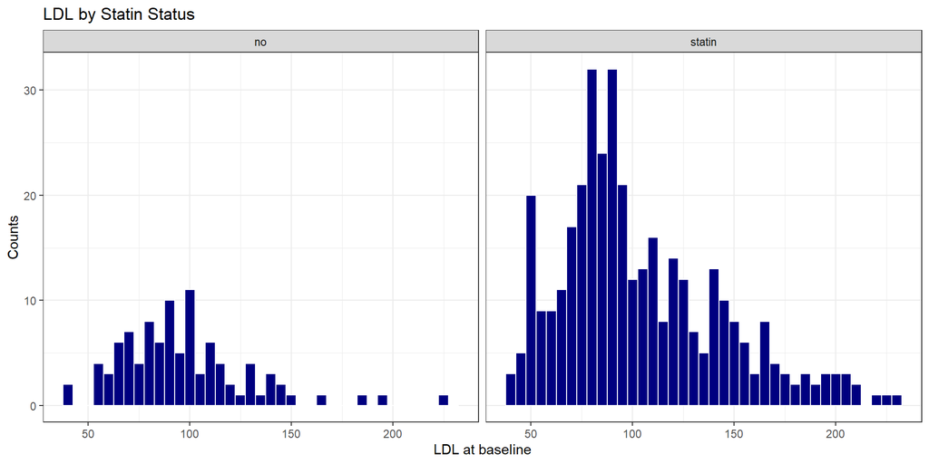

## Faceted Normal Q-Q plots

```r
ggplot(class05, aes(sample = ldl)) +
  geom_qq() + geom_qq_line(col = "purple") +
  facet_wrap(~ stat_f) +
  labs(x = "Standard Normal distribution", y = "LDL at baseline")
```

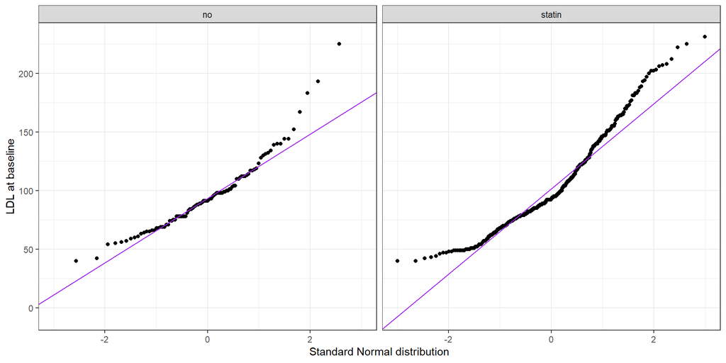

## Comparing `ldl` by `statin` level

- LDL data in each statin group are skewed to the right, with the mean higher than the median.

```r
class05 |> group_by(stat_f) |> reframe(lovedist(ldl)) |>
  kable(digits = 1) |> kable_styling(font_size = 28)
```

| stat_f | n | miss | mean | sd | med | mad | min | q25 | q75 | max |
| --- | --- | --- | --- | --- | --- | --- | --- | --- | --- | --- |
| no | 97 | 0 | 96.3 | 31.6 | 91 | 28.2 | 40 | 75 | 112 | 225 |
| statin | 367 | 0 | 103.4 | 39.5 | 93 | 34.1 | 40 | 77 | 126 | 231 |

- Were these data collected using matched/paired samples or using independent samples?

## Estimating Difference in Means

Building **90%** uncertainty intervals for the difference in population means using independent samples<sup>1</sup>.

- Ordinary least squares regression model (same as a pooled t procedure here) fit with `lm()`.
- Bayesian regression model with a weakly informative prior fit with `stan_glm()` from **rstanarm**.
- Welch t method without pooling standard deviations.
- Bootstrap confidence interval approach.
[^4]: [Chapter 6](https://thomaselove.github.io/431-book/06_twogroups.html) has more details and examples.

## Using `lm()` to fit an OLS model

```r
fit4 <- lm(ldl ~ stat_f, data = class05)

model_parameters(fit4, ci = 0.90, pretty_names = FALSE)
```

```
Parameter    | Coefficient |   SE |          90% CI | t(462) |      p
---------------------------------------------------------------------
(Intercept)  |       96.26 | 3.86 | [89.90, 102.62] |  24.94 | < .001
stat_fstatin |        7.17 | 4.34 | [ 0.02,  14.32] |   1.65 | 0.099
```

- Comparing those on a statin to those that aren’t, our model suggests that the mean difference in LDL levels is 7.17 mg/dl with 90% uncertainty interval (0.02, 14.32) mg/dl.

## Pooled t = same as OLS

```r
fit5 <- t.test(ldl ~ stat_f, data = class05,
               var.equal = TRUE, conf.level = 0.90)

model_parameters(fit5, ci = 0.90, pretty_names = FALSE)
```

```
Two Sample t-test

Parameter |  Group | stat_f = no | stat_f = statin | Difference
---------------------------------------------------------------
ldl       | stat_f |       96.26 |          103.43 |      -7.17

Parameter |          90% CI | t(462) |     p
--------------------------------------------
ldl       | [-14.32, -0.02] |  -1.65 | 0.099

Alternative hypothesis: true difference in means between group no and group statin is not equal to 0
```

## Bayesian regression model

```r
set.seed(43103)

fit6 <- stan_glm(ldl ~ stat_f, data = class05, refresh = 0)

model_parameters(fit6, ci = 0.90, pretty_names = FALSE)
```

```
Parameter    | Median |          90% CI |     pd |  Rhat | ESS (tail) |                    Prior
------------------------------------------------------------------------------------------------
(Intercept)  |  96.32 | [89.93, 102.70] |   100% | 0.999 |       2404 | Normal (101.93 +- 95.20)
stat_fstatin |   7.07 | [-0.26,  14.08] | 94.25% | 1.000 |       2168 |  Normal (0.00 +- 233.87)
```

## Welch t approach (no pooling)

```r
fit7 <- t.test(ldl ~ stat_f, data = class05,
               var.equal = FALSE, conf.level = 0.90)

model_parameters(fit7, ci = 0.90, pretty_names = FALSE)
```

```
Welch Two Sample t-test

Parameter |  Group | stat_f = no | stat_f = statin | Difference
---------------------------------------------------------------
ldl       | stat_f |       96.26 |          103.43 |      -7.17

Parameter |          90% CI | t(183.36) |     p
-----------------------------------------------
ldl       | [-13.48, -0.86] |     -1.88 | 0.062

Alternative hypothesis: true difference in means between group no and group statin is not equal to 0
```

## Bootstrap, with `MKinfer`

```r
set.seed(43104)
boot.t.test(ldl ~ stat_f, var.equal = TRUE, R = 2000,
  data = class05, conf.level = 0.90)
```

```
    Bootstrap Two Sample t-test

data:  ldl by stat_f
number of bootstrap samples:  2000
bootstrap p-value = 0.093
bootstrap difference of means (SE) = -7.251915 (4.34287)
90 percent bootstrap percentile confidence interval:
 -14.2840024  -0.1761131

Results without bootstrap:
t = -1.6523, df = 462, p-value = 0.09915
alternative hypothesis: true difference in means is not equal to 0
90 percent confidence interval:
 -14.32216921  -0.01795271
sample estimates:
    mean in group no mean in group statin
            96.25773            103.42779
```

## Bootstrap without pooling sd

```r
set.seed(43105)
boot.t.test(ldl ~ stat_f, var.equal = FALSE, R = 2000,
  data = class05, conf.level = 0.90)
```

```
    Bootstrap Welch Two Sample t-test

data:  ldl by stat_f
number of bootstrap samples:  2000
bootstrap p-value = 0.056
bootstrap difference of means (SE) = -7.0623 (3.784715)
90 percent bootstrap percentile confidence interval:
 -12.9985828  -0.8738097

Results without bootstrap:
t = -1.8786, df = 183.36, p-value = 0.06188
alternative hypothesis: true difference in means is not equal to 0
90 percent confidence interval:
 -13.4797701  -0.8603518
sample estimates:
    mean in group no mean in group statin
            96.25773            103.42779
```

## 90% Uncertainty Intervals

Mean difference in baseline LDL for “Statin” group minus “No Statin” group. Do our conclusions change?

| Approach | Estimate & 90% Interval |
| --- | --- |
| Linear model / Pooled t | 7.17 (0.02, 14.32) |
| Bayesian fit: `stan_glm()` | 7.07 (-0.26, 14.08) |
| Welch t (unpooled sd) | 7.17 (0.86, 13.48) |
| Bootstrap, pooled sd | 7.25 (0.18, 14.28) |
| Bootstrap, unpooled sd | 7.06 (0.87, 13.00) |